# Analysis: Evaluations of BFI Subscales and IAT

analysis

Theresa Halbritter

11 Januar, 2024

# Dependencies

```r
library(tidyverse)
library(knitr)
library(kableExtra)
library(janitor)
library(scales)
library(psych)
```

```r
library(ggplot2)
library(dplyr)
library(ltm)
library(report)
library(cowplot)
library(patchwork)
```

# Get Data

```r
data_processed <- read_csv("../data/processed/data_processed.csv")
```

#Sample descriptives

## Sample size before exclusions

Create a table with the total number of participants before exclusions.

```r
data_processed |>
  count(name = "n") |>
  kable() |>
  add_header_above(header = c("Whole sample" = 1)) |>
  kable_classic(full_width = FALSE)
```

| Whole sample n |
| --- |
| 1932 |

## Sample Size after exclusions

Exclude participants using the master exclusion variable.

```r
data_processed_after_exclusions <- data_processed %>%
  filter(exclude_participant == "include" & !is.na(exclude_participant))
```

## Table with total number of participants

Create a table with the total number of participants after exclusions.

```r
data_processed_after_exclusions |>
  count(name = "n") |>
  kable() |>
  add_header_above(header = c("For analysis" = 1)) |>
  kable_classic(full_width = FALSE)
```

| For analysis n |
| --- |
| 163 |

## Create demographics table

Create demographics tables that summarise the mean and SD age, and the frequency and percentage of men vs women in the sample. Report the proportion of participants for which each demographics variable was available.

### Age

```r
data_processed_after_exclusions |>
  mutate(age = as.numeric(age)) |>
  summarise(Mean = mean(age, na.rm = TRUE),
            SD = sd(age, na.rm = TRUE)) |>
  mutate_all(.funs = janitor::round_half_up, digits = 1) |>
  kable() |>
  add_header_above(header = c("Age" = 2)) |>
  kable_classic(full_width = FALSE)
```

| Age Mean | Age SD |
| --- | --- |
| 30.5 | 11.2 |

### Gender

```r
data_processed_after_exclusions |>
  group_by(sex) |>
  summarise(n = n()) |>
  mutate(Percent = paste0(round_half_up((n / sum(n)) * 100, 1), "%")) |>
  kable() |>
  kable_classic(full_width = FALSE)
```

| sex | n | Percent |
| --- | --- | --- |
| f | 87 | 53.4% |
| m | 54 | 33.1% |
| missing/other/error | 22 | 13.5% |

### Proportion available for Age

```r
availability_age <-
  (sum(!is.na(data_processed_after_exclusions$age) & data_processed_after_exclusions$age != "other/missing/error") / nrow(data_processed_after_exclusions)) |>
  round(2)

print(paste0("Age was available for ", availability_age))
```

```
## [1] "Age was available for 0.87"
```

### Proportion available for Gender

```r
availability_sex <-
  (sum(!is.na(data_processed_after_exclusions$sex) & data_processed_after_exclusions$sex %in% c("f", "m")) / nrow(data_processed_after_exclusions)) |>
  round(2)

print(paste0("Gender was available for ", availability_sex))
```

```
## [1] "Gender was available for 0.87"
```

## BFI

### Chronbach´s alpha BFI

Calculate Cronbach’s alpha for each of the BFI subscales.

```r
# Function
calculate_alpha_subscale <- function(data, subscale, n) {
  items_subscale <- paste0("bfi_", subscale, 1:n)

  subscale_data <- data[, items_subscale, drop = FALSE]

  # Remove NA´s
  subscale_data <- na.omit(subscale_data)

  # Check if enough data is available after removing NAs
  if (nrow(subscale_data) < 3) {
    warning("Nicht genügend Daten für die Berechnung von Cronbach's Alpha.")
    return(NA)
  }

  # Calculating Cronbach's Alpha
  alpha_result <- psych::alpha(subscale_data)
  alpha_value <- alpha_result$total
  return(alpha_value)
}

# Calculating Chronbachs Alpha for each subscale
alpha_agreeableness <- calculate_alpha_subscale(data_processed_after_exclusions, "a", 9)
alpha_conscientiousness <- calculate_alpha_subscale(data_processed_after_exclusions, "c", 9)
alpha_extraversion <- calculate_alpha_subscale(data_processed_after_exclusions, "e", 8)
alpha_neuroticism <- calculate_alpha_subscale(data_processed_after_exclusions, "n", 8)
alpha_openness <- calculate_alpha_subscale(data_processed_after_exclusions, "o", 10)

# show results
alpha_agreeableness
```

```
##  raw_alpha std.alpha   G6(smc) average_r      S/N        ase     mean        sd
##  0.7827912 0.7950292 0.8135756 0.3011741 3.878744 0.03491114 4.393939 0.7688613
##   median_r
##  0.3051145
```

```r
alpha_conscientiousness
```

```
##  raw_alpha std.alpha   G6(smc) average_r     S/N        ase     mean        sd
##  0.8107809 0.8194388 0.8385494 0.3352188 4.53829 0.03207928 4.358519 0.8007282
##   median_r
##  0.3221202
```

```r
alpha_extraversion
```

```
##  raw_alpha std.alpha   G6(smc) average_r      S/N        ase  mean        sd
##  0.8181232 0.8145321 0.8341984 0.3544101 4.391768 0.03110611 3.865 0.8654791
##   median_r
##  0.3677282
```

```r
alpha_neuroticism
```

```
##  raw_alpha std.alpha   G6(smc) average_r      S/N        ase  mean        sd
##  0.7786548  0.780091 0.7926929 0.3071995 3.547335 0.03817666 3.075 0.8069588
##  median_r
##  0.330617
```

```r
alpha_openness
```

```
##  raw_alpha std.alpha   G6(smc) average_r      S/N        ase     mean        sd
##  0.8084322  0.818019 0.8595504 0.3101107 4.495079 0.03058358 4.621591 0.7342913
##   median_r
##  0.3027808
```

Results for Cronbach´s Alpha: agreeableness: 0.78 / conscientiousness:0.81 / extraversion: 0.82 / neuroticism:0.78 / openness: 0.81

### Histogram distribution of the BFI subscales

Create series of histograms of the distribution of scores on each of the BFI subscales and the IAT.

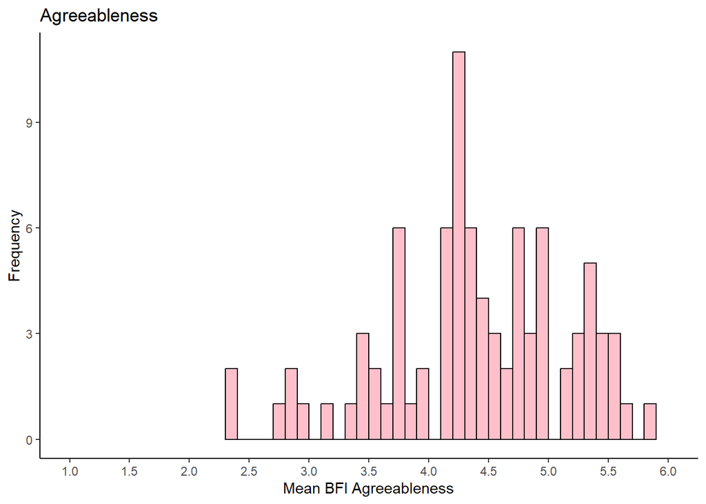

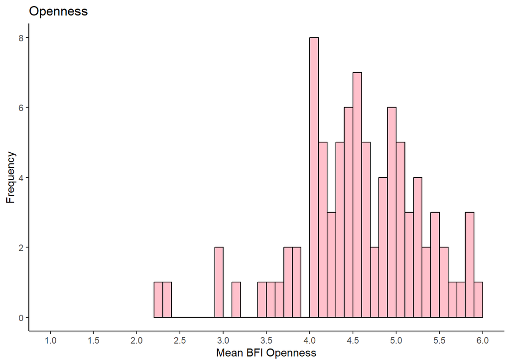

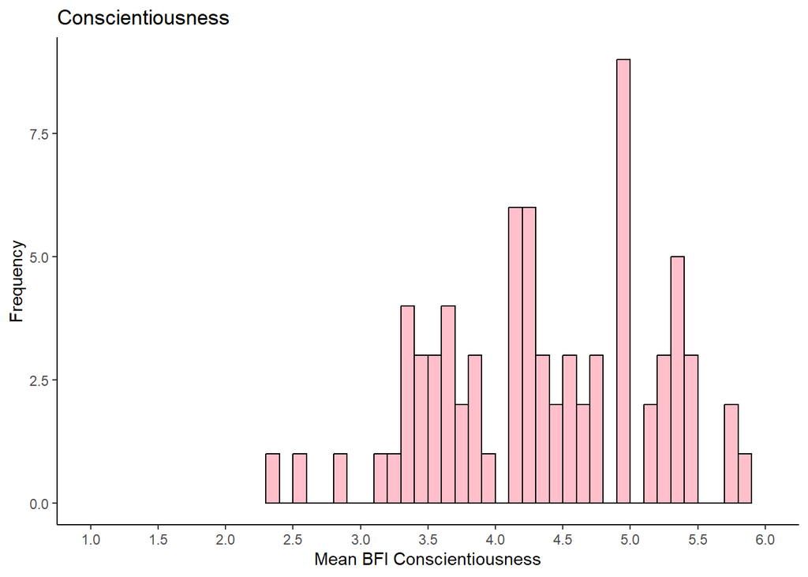

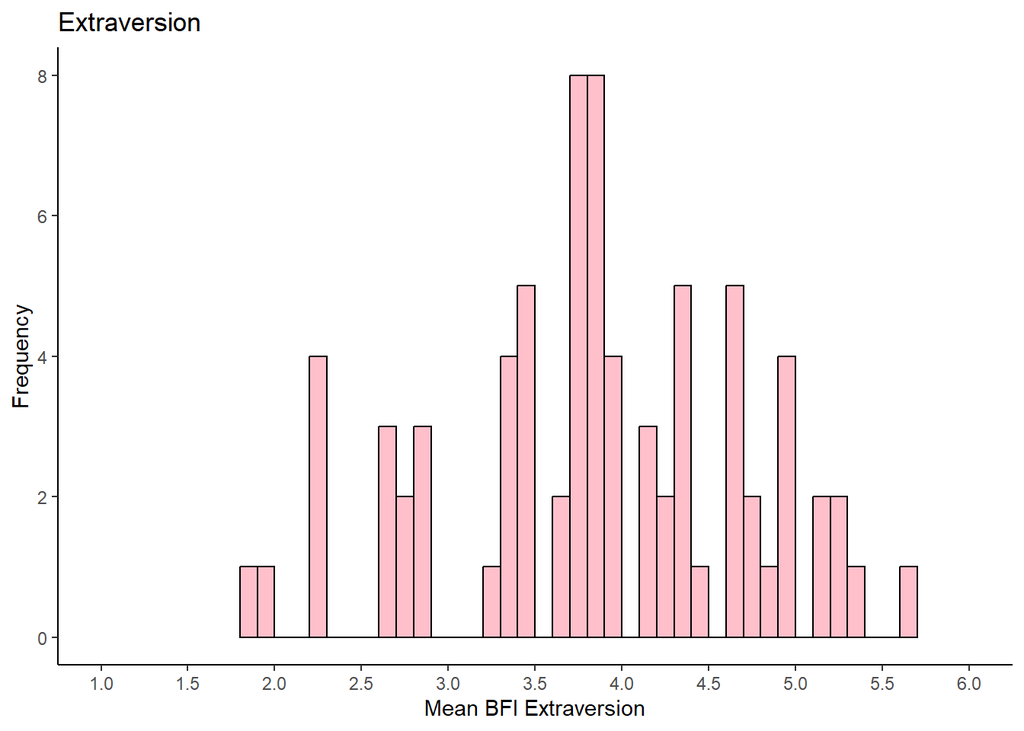

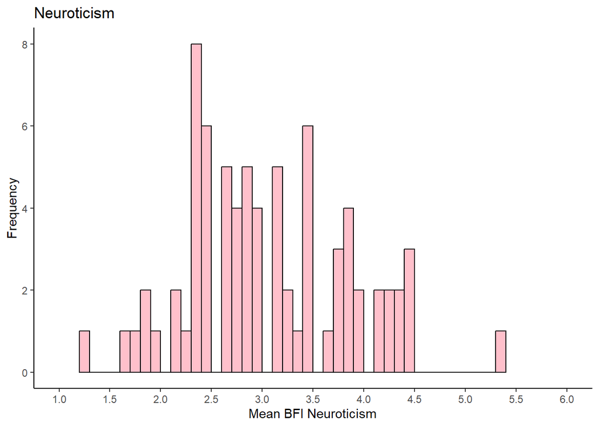

```r
histogram_distribution_subscales <- function(data, subscale, title, xlab) {
  ggplot(data, aes(x = !!sym(subscale))) +
    geom_histogram(binwidth = 0.1,
                   boundary = 0,
                   fill = "pink",
                   color = "black") +
    xlab(xlab) +
    ylab("Frequency") +
    ggtitle(title) +
    theme_classic() +
    scale_x_continuous(breaks = pretty_breaks(n = 9)) +
    coord_cartesian(xlim = c(1, 6))
}

bfi_subscales <- c("mean_bfi_a", "mean_bfi_o", "mean_bfi_c", "mean_bfi_e", "mean_bfi_n")
custom_titles <- c("Agreeableness", "Openness", "Conscientiousness", "Extraversion", "Neuroticism")
custom_xlabels <- c("Mean BFI Agreeableness", "Mean BFI Openness", "Mean BFI Conscientiousness", "Mean BFI Extraversion", "Mean BFI Neuroticism")

for (i in seq_along(bfi_subscales)) {
  print(histogram_distribution_subscales(data_processed_after_exclusions, bfi_subscales[i], custom_titles[i], custom_xlabels[i]))
}
```

### Histogram for D_Scores

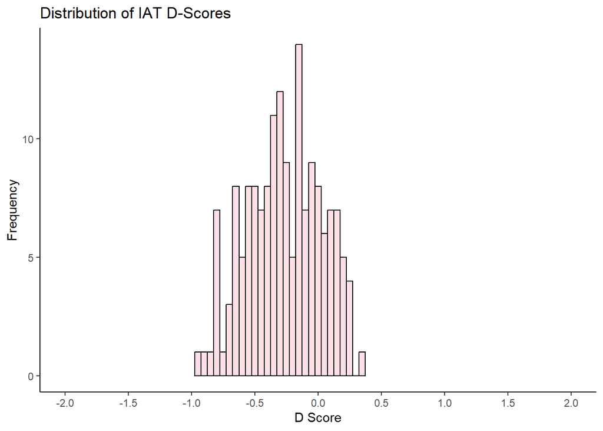

```r
histrogram_d_scores <- function(data, variable, title) {
  ggplot(data = data, aes(x = .data[[variable]])) +
    geom_histogram(binwidth = 0.05, fill = "pink", color = "black", alpha = 0.5) +
    labs(title = "Distribution of IAT D-Scores", x = "D Score", y = "Frequency") +
    theme_classic() +
    coord_cartesian(xlim = c(-2,2))+
    scale_x_continuous(breaks = pretty_breaks(n = 10))
}

histrogram_d_scores(data_processed_after_exclusions, "D_Score", "IAT D-Score")
```

### Correlation Matrix IAT and BFI Create a table with a correlation matrix of the Pearson’s r correlations between the IAT and the BFI subscales rounded to two decimal places.

```r
data_correlation_matrix <- data_processed_after_exclusions |>
  dplyr::select(c(mean_bfi_a, mean_bfi_c, mean_bfi_e, mean_bfi_n, mean_bfi_o, D_Score))

cor_matrix <- cor(data_correlation_matrix, use = "pairwise.complete.obs")

cor_matrix_rounded <- round(cor_matrix, 2)
print(cor_matrix_rounded)
```

```
##            mean_bfi_a mean_bfi_c mean_bfi_e mean_bfi_n mean_bfi_o D_Score
## mean_bfi_a       1.00         NA         NA         NA       0.14   -0.03
## mean_bfi_c         NA       1.00       0.09      -0.33         NA   -0.07
## mean_bfi_e         NA       0.09       1.00      -0.10         NA    0.10
## mean_bfi_n         NA      -0.33      -0.10       1.00         NA    0.07
## mean_bfi_o       0.14         NA         NA         NA       1.00    0.01
## D_Score         -0.03      -0.07       0.10       0.07       0.01    1.00
```

## Testing Hypotheses

### Men and Women differ on their scores on the IAT

Run a t-test to test the hypothesis that men and women differ on their scores on the IAT. Report and interpret the results using {report}.

```r
scores_men <- data_processed_after_exclusions$D_Score[data_processed_after_exclusions$sex == "m"]
scores_women <- data_processed_after_exclusions$D_Score[data_processed_after_exclusions$sex == "f"]

# Perform the t-test
t_test_result <- report(t.test(scores_men, scores_women, alternative = "two.sided"))

# Print the t-test result
t_test_result
```

```
## Effect sizes were labelled following Cohen's (1988) recommendations.
##
## The Welch Two Sample t-test testing the difference between scores_men and
## scores_women (mean of x = -0.28, mean of y = -0.24) suggests that the effect is
## negative, statistically not significant, and very small (difference = -0.04,
## 95% CI [-0.14, 0.06], t(113.82) = -0.73, p = 0.470; Cohen's d = -0.13, 95% CI
## [-0.46, 0.21])
```

### Regressions: Each BFI subscale predicts IAT scores

Run a series of regressions to test the hypotheses that each BFI subscale predicts IAT scores. Run separate regressions for each subscale rather than a multiple regression. Report and interpret the results using {report}.

```r
bfi_subscale_names <- c("mean_bfi_a", "mean_bfi_c", "mean_bfi_e", "mean_bfi_n", "mean_bfi_o")

for (subscale in bfi_subscale_names) {
  formula <- as.formula(paste("D_Score ~", subscale))
  regression_model <- report(lm(formula, data = data_processed_after_exclusions))
  cat("Regression for", subscale, "\n")
  print(summary(regression_model))
  cat("\n")
}
```

```
## Regression for mean_bfi_a
## We fitted a linear model to predict D_Score with mean_bfi_a. The model's
## explanatory power is very weak (R2 = 1.20e-03, adj. R2 = -0.01). The model's
## intercept is at -0.20 (95% CI [-0.57, 0.18]). Within this model:
##
##   - The effect of mean bfi a is statistically non-significant and negative (beta
## = -0.01, 95% CI [-0.10, 0.07], t(86) = -0.32, p = 0.749, Std. beta = -0.03)
##
## Regression for mean_bfi_c
## We fitted a linear model to predict D_Score with mean_bfi_c. The model's
## explanatory power is very weak (R2 = 4.53e-03, adj. R2 = -9.11e-03). The
## model's intercept is at -0.18 (95% CI [-0.54, 0.19]). Within this model:
##
##   - The effect of mean bfi c is statistically non-significant and negative (beta
## = -0.02, 95% CI [-0.11, 0.06], t(73) = -0.58, p = 0.566, Std. beta = -0.07)
##
## Regression for mean_bfi_e
## We fitted a linear model to predict D_Score with mean_bfi_e. The model's
## explanatory power is very weak (R2 = 0.01, adj. R2 = -3.11e-03). The model's
## intercept is at -0.41 (95% CI [-0.71, -0.11]). Within this model:
##
##   - The effect of mean bfi e is statistically non-significant and positive (beta
## = 0.03, 95% CI [-0.04, 0.11], t(73) = 0.88, p = 0.383, Std. beta = 0.10)
##
## Regression for mean_bfi_n
## We fitted a linear model to predict D_Score with mean_bfi_n. The model's
## explanatory power is very weak (R2 = 5.08e-03, adj. R2 = -8.55e-03). The
## model's intercept is at -0.36 (95% CI [-0.62, -0.10]). Within this model:
##
##   - The effect of mean bfi n is statistically non-significant and positive (beta
## = 0.03, 95% CI [-0.06, 0.11], t(73) = 0.61, p = 0.544, Std. beta = 0.07)
##
## Regression for mean_bfi_o
## We fitted a linear model to predict D_Score with mean_bfi_o. The model's
## explanatory power is very weak (R2 = 9.24e-05, adj. R2 = -0.01). The model's
## intercept is at -0.27 (95% CI [-0.69, 0.14]). Within this model:
##
##   - The effect of mean bfi o is statistically non-significant and positive (beta
## = 3.96e-03, 95% CI [-0.08, 0.09], t(86) = 0.09, p = 0.929, Std. beta =
## 9.61e-03)
```

### Scatter Plot: Each BFI subscale predicts IAT scores

Create series of scatter plots of how BFI subscale scores predict IAT scores. Add regression lines. These plots therefore illustrate the same results as the regressions above. Make the plots presentable and publication quality- you may decide the details of this with one exception: Extreme scores on the IAT (defined as participants whose scores in the top and bottom 10% of IAT scores) should use a triangular shape rather than a dot. A single combined plot should be created, containing 5 component plots, with the personality facet being examined in each clearly labelled. This plot should be printed in the html file but also saved to disk as both png/pdf.

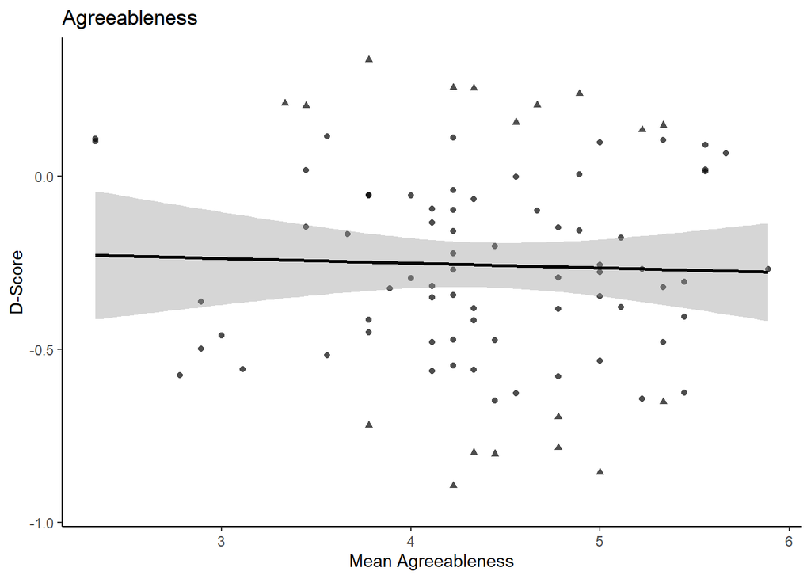

```r
# Calculate D Score cutoffs
iat_score_cutoff_top <- quantile(data_processed_after_exclusions$D_Score, 0.9, na.rm = TRUE)
iat_score_cutoff_bottom <- quantile(data_processed_after_exclusions$D_Score, 0.1, na.rm = TRUE)

# Create a column indicating extreme or normal D scores
data_processed_after_exclusions <- data_processed_after_exclusions |>
  mutate(extreme_iat = ifelse(D_Score >= iat_score_cutoff_top | D_Score <= iat_score_cutoff_bottom,
                              "extreme",
                              "normal"))

# Function to create scatter plot
function_scatter_plot_bfi <- function(column, name_subscale) {
  ggplot(data_processed_after_exclusions, aes(x = get(column), y = D_Score)) +
    geom_point(aes(shape = extreme_iat), alpha = 0.7) +
    scale_shape_manual(values = c(extreme = 17, normal = 16)) +
    geom_smooth(method = "lm",color = "black") +
    ggtitle(name_subscale) +
    xlab(paste0("Mean ", name_subscale)) +
    ylab("D-Score") +
    theme_classic() +
    theme(legend.position = "none")
}

agreeableness_plot <- function_scatter_plot_bfi("mean_bfi_a", "Agreeableness")
conscientiousness_plot <- function_scatter_plot_bfi("mean_bfi_c", "Conscientiousness")
extraversion_plot <- function_scatter_plot_bfi("mean_bfi_e", "Extraversion")
neuroticism_plot <- function_scatter_plot_bfi("mean_bfi_n", "Neuroticism")
openness_plot <- function_scatter_plot_bfi("mean_bfi_o", "Openness")

print(agreeableness_plot)
```

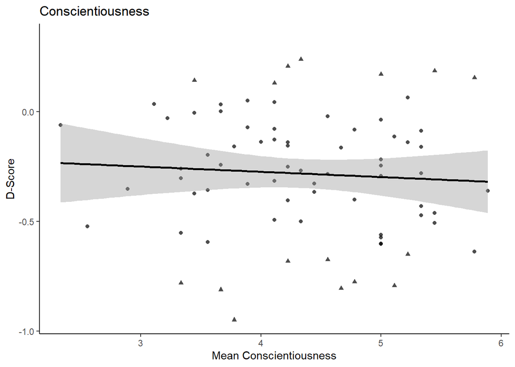

```r
print(conscientiousness_plot)
```

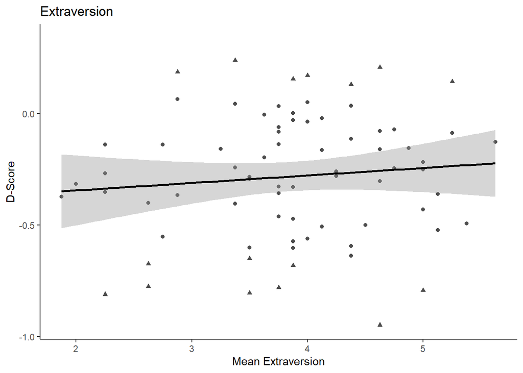

```r
print(extraversion_plot)
```

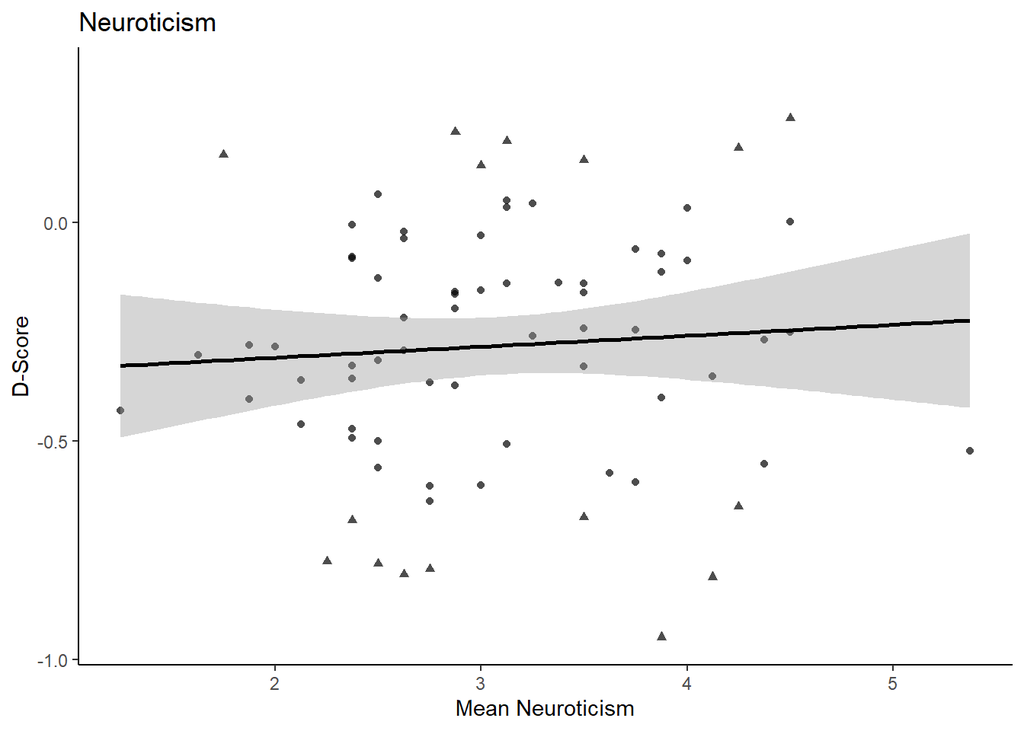

```r
print(neuroticism_plot)
```

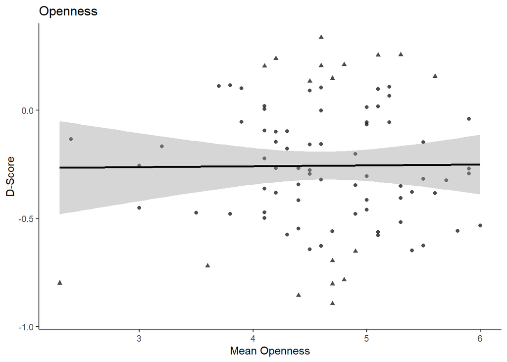

```r
print(openness_plot)
```

Combine these scatter plots into one ggplot object using {patchwork} and print the combined plot in your .Rmd and .html. Save the combined plot to disk as a .pdf and .png in the “communications” folder.

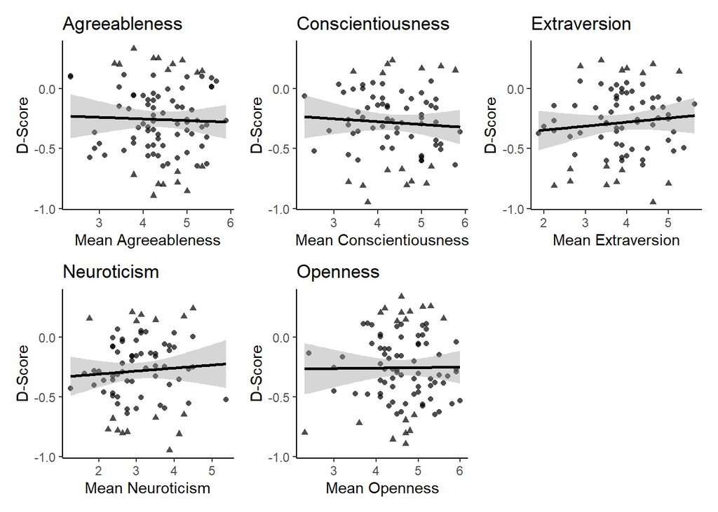

```r
combining_bfi_plots <- agreeableness_plot + conscientiousness_plot + extraversion_plot + neuroticism_plot + openness_plot
print(combining_bfi_plots)
```

```r
ggsave("../communications/combined_plot.png", combining_bfi_plots, width = 18, height = 12, units = "cm")
ggsave("../communications/combined_plot.pdf", combining_bfi_plots, width = 18, height = 12, units = "cm")
```